# Analyzing and Predicting Chocolate Sales

## Introduction

Recently, my social media has been bombarded with videos of chocolate made in Dubai. It's essentially a chocolate bar filled with pistachio and right now it seems to be making its rounds. The reviews so far have been positive and although I have not tried it, it set the direction for this project. Chocolate is one of the most used ingredients in desserts around the world and is quite a popular dessert itself so I decided to do a market analysis with a dataset of chocolate sales around the world. The dataset used for this project was obtained from Kaggle https://www.kaggle.com/datasets/atharvasoundankar/chocolate-sales by Atharva Soundankar.

## Loading libraries and reading dataset

```python
import pandas as pd
import matplotlib.pyplot as plt
import seaborn as sns
from prophet import Prophet
```

```python
data = pd.read_csv('Chocolate Sales.csv')


print("\n(Data successfully loaded.)")
```

```
(Data successfully loaded.)
```

## Data inspection and Cleaning

```python
display(data.head())
```

|  | Sales Person | Country | Product | Date | Amount | Boxes Shipped |
| --- | --- | --- | --- | --- | --- | --- |
| 0 | Jehu Rudeforth | UK | Mint Chip Choco | 04-Jan-22 | $5,320 | 180 |
| 1 | Van Tuxwell | India | 85% Dark Bars | 01-Aug-22 | $7,896 | 94 |
| 2 | Gigi Bohling | India | Peanut Butter Cubes | 07-Jul-22 | $4,501 | 91 |
| 3 | Jan Morforth | Australia | Peanut Butter Cubes | 27-Apr-22 | $12,726 | 342 |
| 4 | Jehu Rudeforth | UK | Peanut Butter Cubes | 24-Feb-22 | $13,685 | 184 |

```python
data.shape
```

```
(1094, 6)
```

```python
data.dtypes
```

```
Sales Person     object
Country          object
Product          object
Date             object
Amount           object
Boxes Shipped     int64
dtype: object
```

```python
#data cleaning
#check for nan values, get aggregations
data.describe()
```

|  | Boxes Shipped |
| --- | --- |
| count | 1094.000000 |
| mean | 161.797989 |
| std | 121.544145 |
| min | 1.000000 |
| 25% | 70.000000 |
| 50% | 135.000000 |
| 75% | 228.750000 |
| max | 709.000000 |

```python
data['Product'].describe()
```

```
count               1094
unique                22
top       50% Dark Bites
freq                  60
Name: Product, dtype: object
```

```python
data['Country'].unique()
```

```
array(['UK', 'India', 'Australia', 'New Zealand', 'USA', 'Canada'],
      dtype=object)
```

```python
# data['Date'] = pd.to_datetime(data['Date']) # Convert to datetime for future calculations
# date_range = str(data['Date'].dt.date.min()) + ' to ' +str(data['Date'].dt.date.max())
# print(date_range)
```

## Checking for NaN values

From the description of the dataset on Kaggle, I know it is clean and does not require much processing, however I will still perform the necessary checks on the data.

```python
#nan_mask = pd.isna(data)
nan_count = data.isna().sum() #will sum across columns
print(nan_count)
```

```
Sales Person     0
Country          0
Product          0
Date             0
Amount           0
Boxes Shipped    0
dtype: int64
```

## Handling NaN Values

Rows containing NaN values can either be dropped using pd.DataFrame.dropna, or imputed using the mean and median (for continuous data) and mode (for categorical data). Alternatively you can develop a separate regression/classification model to predict any values that may be missing.

## Changing Dataypes

As previously shown, some of the columns are object datatypes. In order to visualize the data, they must be converted to other datatypes

```python
#Changing date to datetime
data['Date'] = pd.to_datetime(data['Date']) # Convert to datetime for future calculations
date_range = str(data['Date'].dt.date.min()) + ' to ' +str(data['Date'].dt.date.max())
print(date_range)
```

```
2022-01-03 to 2022-08-31
```

```python
# Changing Amount to Float for further exploration
data['Amount'] = data['Amount'].str.replace('$', '', regex=False)
data['Amount'] = data['Amount'].str.replace(',', '', regex=False).astype(float)
#data['Amount'] = data['Amount'].replace('[\$,]', '', regex=True).astype(float)
```

```python
data['Amount']
```

```
0        5320.0
1        7896.0
2        4501.0
3       12726.0
4       13685.0
         ...
1089     4410.0
1090     6559.0
1091      574.0
1092     2086.0
1093     5075.0
Name: Amount, Length: 1094, dtype: float64
```

## Visualizing the data

### Most Boxes Shipped by Country

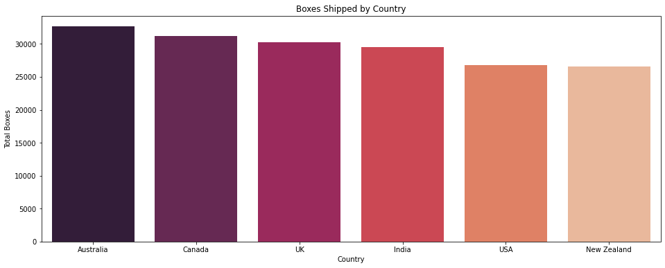

```python
#The following code plots a bar chart of the most boxes shipped by each country


country = data.groupby(by=['Country'])['Boxes Shipped'].sum().sort_values(ascending = False)
plt.figure(figsize=(16,6))
sns.barplot(x=country.index, y=country.values, palette='rocket', hue = country.index)
plt.title('Boxes Shipped by Country')
plt.xlabel('Country')
plt.ylabel('Total Boxes')
```

## Amount in Sales by Country

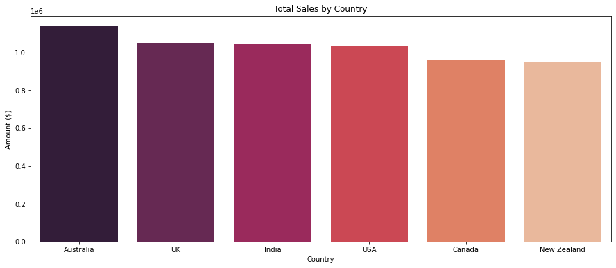

```python
#The following code plots a bat chart of the Total Amount in sales by country

country_amount = data.groupby(by=['Country'])['Amount'].sum().sort_values(ascending = False)
plt.figure(figsize=(15,6))
sns.barplot(x=country_amount.index, y=country_amount.values, palette='rocket', hue = country_amount.index)
plt.title('Total Sales by Country')
plt.xlabel('Country')
plt.ylabel('Amount ($)')
plt.show()
```

From a comparison of both graphs, Australia has the most boxes shipped and so has the most revenue, however, this pattern does not continue for the rest of the countries. While Canada has the second most boxes shipped, it places fifth in the total amount generated by countries. The UK has shipped the third most boxes, but ranks second in amount generated. This could be due to many factors, including the type of chocolate shipped as well as the destinations (destinations further away would be more expensive to transport). However, we do not have the destination data so this will remain as speculation for now.

## Most Popular Product By Country

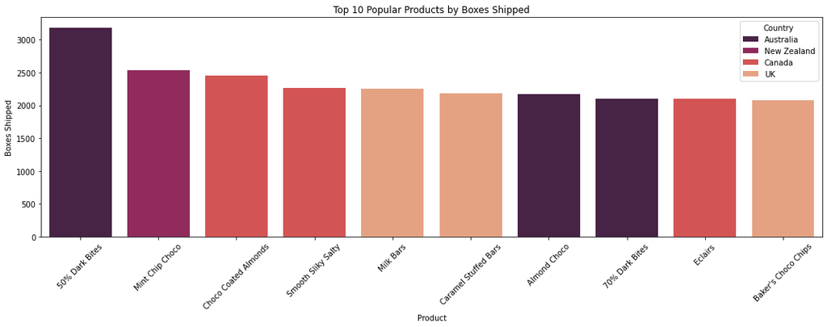

```python
#The following code plots a bar chart showing the most popular product by countrt

country_product = data.groupby(by=['Product', 'Country'])['Boxes Shipped'].sum().sort_values(ascending=False).reset_index()

# Take top 10 combinations
top_country_product = country_product.head(10)
plt.figure(figsize=(15, 6))
sns.barplot(
    data=top_country_product,
    x='Product',
    y='Boxes Shipped',
    hue='Country',
    palette= 'rocket'
)

plt.title('Top 10 Popular Products by Boxes Shipped')
plt.ylabel('Boxes Shipped')
plt.xticks(rotation=45)
plt.legend(title='Country')
plt.tight_layout()
plt.show()
```

Please note that here I have defined 'Popular' in terms of the number of units shipped and not by total sales.

## Highest Grossing Products

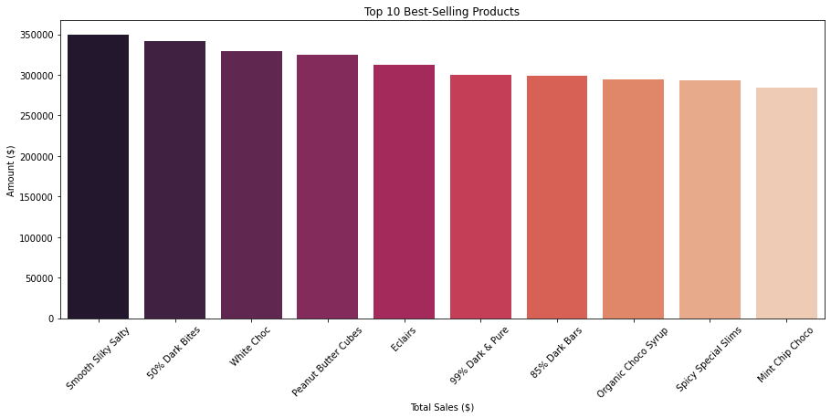

```python
#The following code plots a bar chart for the top 10 products by sales

top_products = data.groupby('Product')['Amount'].sum().sort_values(ascending=False).head(10)

plt.figure(figsize=(15,6))
sns.barplot(x=top_products.index, y=top_products.values, palette='rocket', hue = top_products.index)
plt.title('Top 10 Best-Selling Products')
plt.xlabel('Total Sales ($)')
plt.ylabel('Amount ($)')
plt.xticks(rotation=45)
plt.show()
```

## Top Sales Persons

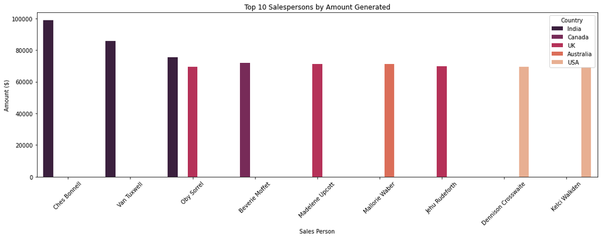

```python
#The following code plots a bar chart of the Sales Persons that generate the most amount in sales

top_sales = data.groupby(['Sales Person', 'Country'])['Amount'].sum().sort_values(ascending = False).reset_index()


top_salespersons = top_sales.head(10)

plt.figure(figsize=(15, 6))
sns.barplot(data=top_salespersons, x='Sales Person', y='Amount', hue='Country',palette= 'rocket')

plt.title('Top 10 Salespersons by Amount Generated')
plt.ylabel('Amount ($)')
plt.xticks(rotation=45)
plt.legend(title='Country')
plt.tight_layout()
plt.show()
```

Initially, only the top five salespersons were plotted. As this figure was increased to ten persons, an interesting observation was noted: The top three salespersons were facilitating shipments out of India, however some of them, such as 'Oby Sorrel' ship boxes from multiple countries, in this example India and the UK. I was previously under the assumption that each salesperson was responsible for one country. If the groupby was redone to only include the salesperson and amounts (no Country aspect), it would not be surprising that the salespersons generating the highest amounts operate in multiple countries. I will check this in the code below.

```python
#The following code calculates the Sales persons with the highest revenue across all countries

overall_top_sales = data.groupby(['Sales Person'])['Amount'].sum().sort_values(ascending = False).reset_index()
display(overall_top_sales.head(15))
```

|  | Sales Person | Amount |
| --- | --- | --- |
| 0 | Ches Bonnell | 320901.0 |
| 1 | Oby Sorrel | 316645.0 |
| 2 | Madelene Upcott | 316099.0 |
| 3 | Brien Boise | 312816.0 |
| 4 | Kelci Walkden | 311710.0 |
| 5 | Van Tuxwell | 303149.0 |
| 6 | Dennison Crosswaite | 291669.0 |
| 7 | Beverie Moffet | 278922.0 |
| 8 | Kaine Padly | 266490.0 |
| 9 | Marney O'Breen | 259742.0 |
| 10 | Barr Faughny | 258713.0 |
| 11 | Roddy Speechley | 251062.0 |
| 12 | Gunar Cockshoot | 238483.0 |
| 13 | Gigi Bohling | 232666.0 |
| 14 | Karlen McCaffrey | 223895.0 |

Here, 'Ches Bonnell' brings in the most amount of revenue across all countries. We can take a closer look at the countries included in the calculation.

```python
ches = data[data['Sales Person'] == 'Ches Bonnell']
display(ches.head(20))
```

|  | Sales Person | Country | Product | Date | Amount | Boxes Shipped |
| --- | --- | --- | --- | --- | --- | --- |
| 56 | Ches Bonnell | New Zealand | Spicy Special Slims | 2022-02-14 | 3556.0 | 18 |
| 110 | Ches Bonnell | India | Spicy Special Slims | 2022-07-06 | 10906.0 | 94 |
| 138 | Ches Bonnell | UK | Smooth Sliky Salty | 2022-07-11 | 5663.0 | 110 |
| 144 | Ches Bonnell | Australia | Eclairs | 2022-07-05 | 4116.0 | 128 |
| 169 | Ches Bonnell | Australia | White Choc | 2022-03-02 | 1043.0 | 202 |
| 202 | Ches Bonnell | UK | Orange Choco | 2022-04-27 | 14238.0 | 54 |
| 206 | Ches Bonnell | Australia | Mint Chip Choco | 2022-02-21 | 9660.0 | 92 |
| 220 | Ches Bonnell | Australia | 70% Dark Bites | 2022-01-12 | 3136.0 | 125 |
| 251 | Ches Bonnell | USA | Orange Choco | 2022-06-10 | 1743.0 | 69 |
| 255 | Ches Bonnell | New Zealand | Milk Bars | 2022-08-17 | 4389.0 | 126 |
| 257 | Ches Bonnell | India | Organic Choco Syrup | 2022-03-08 | 16569.0 | 99 |
| 264 | Ches Bonnell | USA | 70% Dark Bites | 2022-05-11 | 4571.0 | 122 |
| 280 | Ches Bonnell | India | Smooth Sliky Salty | 2022-08-03 | 8043.0 | 18 |
| 286 | Ches Bonnell | UK | Mint Chip Choco | 2022-04-08 | 2688.0 | 209 |
| 302 | Ches Bonnell | Canada | Eclairs | 2022-01-10 | 1876.0 | 172 |
| 329 | Ches Bonnell | New Zealand | Peanut Butter Cubes | 2022-03-04 | 889.0 | 273 |
| 335 | Ches Bonnell | UK | Manuka Honey Choco | 2022-05-30 | 4221.0 | 395 |
| 348 | Ches Bonnell | Canada | Baker's Choco Chips | 2022-03-21 | 7462.0 | 371 |
| 367 | Ches Bonnell | Australia | Smooth Sliky Salty | 2022-05-16 | 7490.0 | 54 |
| 406 | Ches Bonnell | Canada | Spicy Special Slims | 2022-08-05 | 5327.0 | 183 |

As we can see this appears to hold true as the top overall salesperson is 'Ches Bonnell' who arrange sales through multiple countries. This could increases the appeal of the salesperson to a possible client (in this case perhaps a company who is looking to launch a new chocolate product into the global market) as it would indicate a larger network.

## Predicting future chocolate sales

For this section I wanted to include a small example of forecasting future total chocolate sales via Time Series Analysis. Since we have dates of each purchase, I decided to use the Prophet library from Python as it is simple to work with and can take into account any trends and/or seasonality.

```python
#The following code builds a Prophet mode, fits it on the data and makes a prediction of the next amount of sales

m = Prophet()

predict_data = pd.DataFrame()

#making a dataframe with the target column and date

predict_data['ds'] = data['Date'].reset_index(drop = True)
predict_data['y'] = data['Amount'] #target column

#display(predict_data)

m.fit(predict_data)  # fit the model
future = m.make_future_dataframe(periods=30, freq='D') #set parameters to predict the next 30 days
forecast = m.predict(future)
```

```
INFO:prophet:Disabling yearly seasonality. Run prophet with yearly_seasonality=True to override this.
INFO:prophet:Disabling daily seasonality. Run prophet with daily_seasonality=True to override this.
```

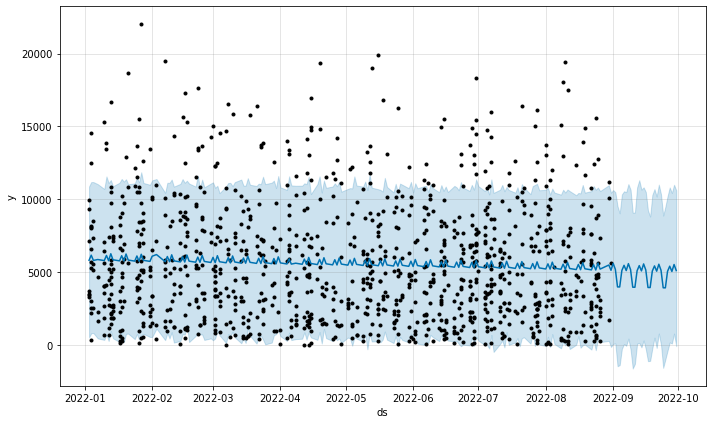

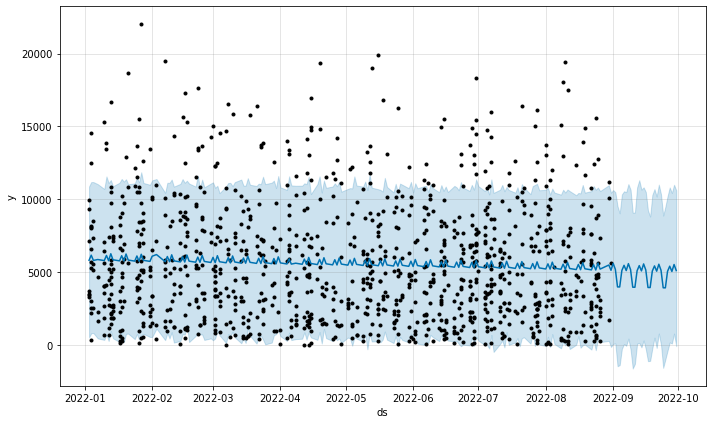

```python
m.plot(forecast)
#plt.show()
```

From this plot, the data is very scattered and the model does not generalize well. The dark blue line does not match with the data points (black dots). The blue shaded area represents the error margins and here, it is very large. Therfore the model needs to be tuned and the data needs to be refined.

## Cross Validation

We can also cross validate the model to get an idea of its performance

```python
from prophet.diagnostics import cross_validation, performance_metrics

#predict 60 days. Train on the first 120 days of data then add increments of 30 and predict
df_cv = cross_validation(m, initial='60 days', period='120 days', horizon = '30 days')

df_metrics = performance_metrics(df_cv)
display(df_metrics.head())
```

```
INFO:prophet:Making 2 forecasts with cutoffs between 2022-04-03 00:00:00 and 2022-08-01 00:00:00
```

|  | horizon | mse | rmse | mae | mape | mdape | smape | coverage |
| --- | --- | --- | --- | --- | --- | --- | --- | --- |
| 0 | 2 days | 1.235876e+07 | 3515.502240 | 2901.463984 | 3.484846 | 0.358664 | 0.490671 | 0.875000 |
| 1 | 3 days | 1.335240e+07 | 3654.093619 | 3136.144533 | 2.966407 | 0.521236 | 0.617024 | 0.880208 |
| 2 | 4 days | 1.283748e+07 | 3582.942434 | 3016.260156 | 2.821395 | 0.521236 | 0.596769 | 0.885417 |
| 3 | 5 days | 1.328632e+07 | 3645.040649 | 3199.887979 | 1.891311 | 0.798752 | 0.686057 | 0.895833 |
| 4 | 7 days | 1.674965e+07 | 4092.633701 | 3491.017995 | 2.229853 | 0.896563 | 0.777166 | 0.879630 |

As expected the rmse values are not very good, which means more work has to be done. There is a limit to how good this model can perform as we only have a few months of data and so will not be able to identify any yearly trends, seasons.

## Second Attempt

|  | ds | y |
| --- | --- | --- |
| 0 | 2022-01-03 | 40425.0 |
| 1 | 2022-01-04 | 77175.0 |
| 2 | 2022-01-05 | 29162.0 |
| 3 | 2022-01-07 | 8666.0 |
| 4 | 2022-01-10 | 51471.0 |
| ... | ... | ... |
| 163 | 2022-08-24 | 43400.0 |
| 164 | 2022-08-25 | 40341.0 |
| 165 | 2022-08-26 | 17556.0 |
| 166 | 2022-08-30 | 23072.0 |
| 167 | 2022-08-31 | 5614.0 |

168 rows × 2 columns

```
INFO:prophet:Disabling yearly seasonality. Run prophet with yearly_seasonality=True to override this.
INFO:prophet:Disabling daily seasonality. Run prophet with daily_seasonality=True to override this.
```

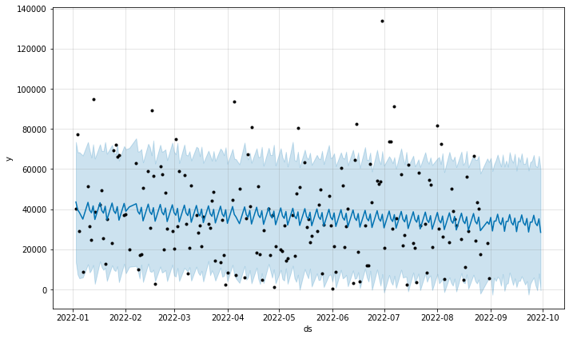

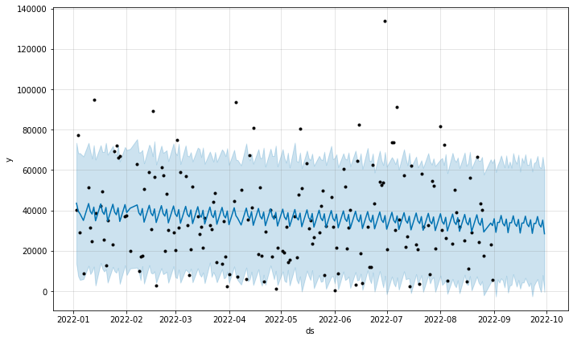

```python
#trying again, but with the data grouped by date

date_groups = data.groupby(['Date'])['Amount'].sum().reset_index()

m2 = Prophet()
predict_data3 = pd.DataFrame()
predict_data3['ds'] = date_groups['Date'].reset_index(drop = True)
predict_data3['y'] = date_groups['Amount']

display(predict_data3)

m2.fit(predict_data3)  # df is a pandas.DataFrame with 'y' and 'ds' columns
future3 = m2.make_future_dataframe(periods=30, freq='D')
forecast3 = m2.predict(future3)
m2.plot(forecast3)
```

```python
#predict 60 days. Train on the first 120 days of data then add increments of 30 and predict
df_cv2 = cross_validation(m2, initial='60 days', period='120 days', horizon = '30 days')

df_metrics2 = performance_metrics(df_cv2)
display(df_metrics2.head())
```

```
INFO:prophet:Making 2 forecasts with cutoffs between 2022-04-03 00:00:00 and 2022-08-01 00:00:00
```

|  | horizon | mse | rmse | mae | mape | mdape | smape | coverage |
| --- | --- | --- | --- | --- | --- | --- | --- | --- |
| 0 | 2 days | 1.450039e+09 | 38079.381247 | 30964.280881 | 0.451687 | 0.406750 | 0.586202 | 0.50 |
| 1 | 3 days | 1.531471e+09 | 39134.018570 | 33695.198614 | 1.124999 | 0.606835 | 0.823719 | 0.50 |
| 2 | 4 days | 1.060963e+09 | 32572.424900 | 28513.271808 | 2.371244 | 1.656643 | 0.977044 | 0.75 |
| 3 | 5 days | 5.515058e+08 | 23484.161341 | 22644.217775 | 2.357570 | 1.667156 | 0.946626 | 0.75 |
| 4 | 7 days | 5.649143e+08 | 23767.925844 | 23094.671262 | 2.141690 | 0.665891 | 0.891464 | 0.75 |

Grouping the data by the date did not improve the models accuracy, however the sales per month can be plotted to observe any trends.

|  | month | Amount |
| --- | --- | --- |
| 0 | 2022-01 | 896105.0 |
| 1 | 2022-02 | 699377.0 |
| 2 | 2022-03 | 749483.0 |
| 3 | 2022-04 | 674051.0 |
| 4 | 2022-05 | 752892.0 |
| 5 | 2022-06 | 865144.0 |
| 6 | 2022-07 | 803425.0 |
| 7 | 2022-08 | 743148.0 |

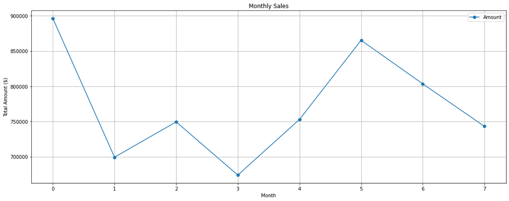

```python
data['month'] = data['Date'].dt.to_period('M')

# Example: Sum 'sales' per month
sales_by_month = data.groupby('month')['Amount'].sum().reset_index()

display(sales_by_month)

sales_by_month.plot(marker='o', linestyle='-', figsize=(15, 6))
plt.title('Monthly Sales')
plt.xlabel('Month')
plt.ylabel('Total Amount ($)')
plt.grid(True)

plt.tight_layout()
plt.show()
```

## Discussion and Recommendations

As can probably be inferred from the forecast plots, the model is not very accurate. There can be many reasons for this, from the quality of the data to the type of model chosen. One area that was not specified in this model was 'Seasonality'. Chocolate sales are very much influenced by seasons, as can be seen from the periodic jumps in amount value (black dots which correspond to higher y hat values). Christmas, Valentines Day and many other international holidays see a higher than usual sales for chocolate. Another area that was not specified in the model was trend. From an overall plot of the target column, are sales generally increasing, decreasing or remaining stable? Both these factors contribute to the model's accuracy and could be added to improve it.

Furthermore, looking at the data points (black dots) on the plots, it looks extremely dense and any model fit would not be able to capture any valuable insights with the data collected at daily intervals. Instead, I think a monthly aggregation of the data might be better to visualise the trends and other patterns throughout the year and improve the model. Of course, data for a complete year would have to be collected.

The data could also be separated by country to account for individual trends and seasons.

Finally, other cleaning methods such as outlier removal can also be done (after thorough verification) to identify the trends even better.

## References

https://stackoverflow.com/questions/10373660/converting-a-pandas-groupby-multiindex-output-from-series-back-to-dataframe

https://facebook.github.io/prophet/docs/diagnostics.html#cross-validation

https://stackoverflow.com/questions/63780573/trying-to-understand-fb-prophet-cross-validation

https://machinelearningmastery.com/time-series-forecasting-with-prophet-in-python/

https://facebook.github.io/prophet/docs/diagnostics.html#cross-validation

```python
print('Project Successfully Run')
```

```
Project Successfully Run
```